# Multivariate Thinking

### Introduction

For this activity we will use the online program [StatKey](https://www.lock5stat.com/StatKey/) to calculate descriptive statistics and construct basic data visualizations.

The goal of the activity is to understand how *multivariate relationships* should influence our understanding of data and shape the decisions we make using that data.

For some background, a multivariate relationship is one where 3 or more variables share relationships with each other. Consider the following example:

- A student’s standardized test scores might influence their chosen major and also their college GPA.
- However, college GPAs tend to differ by major.
- So, when trying to decide if test scores are related to college GPA, we also need to take into account the student’s major to avoid being misled.

$~$

### Activity (part 1, exploration)

[A widely cited study](https://chicagounbound.uchicago.edu/cgi/viewcontent.cgi?article=12039&context=journal_articles), published in 1981, analyzed data on murders which took place during a felony that were committed in the state of Florida between 1972 and 1977. The study recorded numerous attributes pertaining to each of these murders, with the outcome of interest being whether the offender was sentenced to the death penalty. The researchers wanted to decide whether racial bias was present in administration of the death penalty.

A CSV file containing these data can be downloaded by clicking the following link:

- https://remiller1450.github.io/data/DeathPenaltySentencing.csv

This file will appear in your “Downloads” folder, and you can upload it into StatKey using the “Upload File” button on a appropriate menu. Each row in this file describes a court case identified by the research team, and the columns express the following variables describing each case:

- *OffenderRace* - whether the recorded race of the offender was White or Black.
- *VictimRace* - whether the recorded race of the victim in the case was White or Black.
- *DeathPenalty* - whether the jury returned a death penalty verdict or not.

**Question #1**: Use the “Two Categorical Variables” menu under “Descriptive Statistics” on StatKey to create a *two-way frequency table* displaying the variables *OffenderRace* and *DeathPenalty*. Explore the “Proportions: Row, Column, Overall” buttons and use this information to determine whether there seems to be any relationship between the race of the offender and whether or not they received the death penalty. Justify your assessment by citing 2 numbers from one of the tables you looked at.

**Question #2**: Staying on the “Two Categorical Variables” menu, change the variables displayed to *VictimRace* and *DeathPenalty*. Do these two variables appear related? Briefly explain.

**Question #3**: Again staying on the “Two Categorical Variables” menu, change the variables displayed to *VictimRace* and *OffenderRace*. Do these two variables appear related? Briefly explain.

**Question #4**: Considering what you saw in Questions 2 and 3, do you believe the numbers you cited in Question #1 might be misleading? Briefly explain.

Below are *subsets* of the full death penalty sentencing dataset that contain only the cases involving victims of a single race:

- [This link](https://remiller1450.github.io/data/DeathPenaltyWhiteVic.csv) contains the subset of cases where the victim was White.
- [This link](https://remiller1450.github.io/data/DeathPenaltyBlackVic.csv) contains the subset of cases where the victim was Black.

**Question #5**: For the cases involving a *White victim* (first subset given above), were White and Black offenders sentenced to the death penalty at approximately the same rate? Which group was more likely to receive the death penalty? Briefly explain.

**Question #6**: For the cases involving a *Black victim* (second subset given above), were White and Black offenders sentenced to the death penalty at approximately the same rate? Which group was more likely to receive the death penalty? Briefly explain.

**Question #7**: Given everything you’ve seen so far, explain why White and Black offenders seemed to sentenced to the death penalty at similar rates in Question #1, but in Questions #5 and #6 it was Black offenders that received the death penalty at a much higher rate.

$~$

### Activity (part 2, debriefing)

In this study, “VictimRace” is a **confounding variable**, or a third variable that is associated with both the explanatory and response variables in your analysis. The presence of a confounding variable will obscure the real relationship between the explanatory and response variables.

This obfuscation can go in both directions:

- In the death penalty sentencing example the confounding variable *hid* the fact that there was a relationship between race of the offender and death penalty sentencing.
- The example below will demonstrate the opposite, a scenario where the confounding variable *induces* a relationship between two other variables.

Below are some *naive statistical results* that consider only the variables “sex” and “admit”.

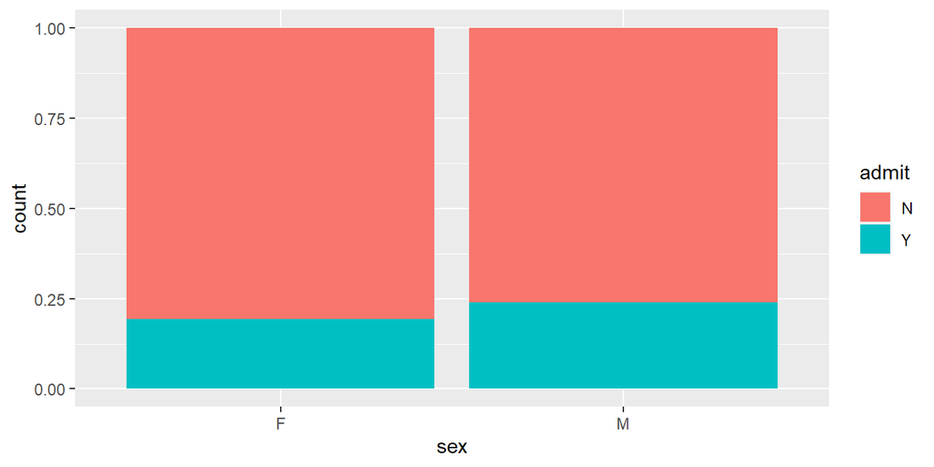

```
##
##  Fisher's Exact Test for Count Data
##
## data:  table(data$sex, data$admit)
## p-value = 1.84e-15
## alternative hypothesis: true odds ratio is not equal to 1
## 95 percent confidence interval:
##  1.225016 1.401925
## sample estimates:
## odds ratio
##   1.310402
```

However, notice that males and females tend to apply to different departments:

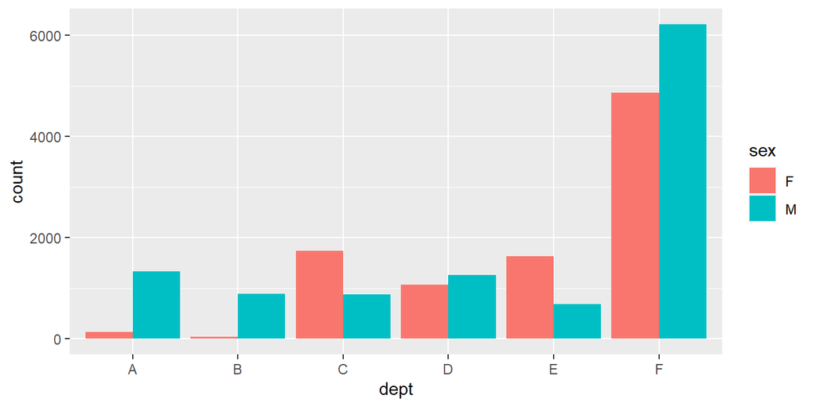

And some departments are more selective than others:

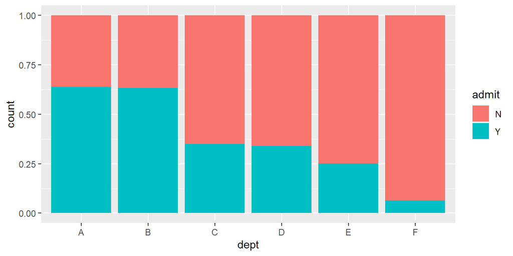

If you’re interested, the difference in the odds of admission is statistically insignificant (p = 0.241) after adjusting for the effect of “department” using a logistic regression model:

```
##
## Call:
## glm(formula = (admit == "Y") ~ sex + dept, family = "binomial",
##     data = data)
##
## Deviance Residuals:
##     Min       1Q   Median       3Q      Max
## -1.4454  -0.7664  -0.3698  -0.3610   2.3510
##
## Coefficients:
##             Estimate Std. Error z value Pr(>|z|)
## (Intercept)  0.61090    0.06678   9.148   <2e-16 ***
## sexM        -0.04984    0.04253  -1.172    0.241
## deptB       -0.02331    0.08721  -0.267    0.789
## deptC       -1.21283    0.07240 -16.751   <2e-16 ***
## deptD       -1.25094    0.07157 -17.479   <2e-16 ***
## deptE       -1.68582    0.07712 -21.860   <2e-16 ***
## deptF       -3.25940    0.06849 -47.587   <2e-16 ***
## ---
## Signif. codes:  0 '***' 0.001 '**' 0.01 '*' 0.05 '.' 0.1 ' ' 1
##
## (Dispersion parameter for binomial family taken to be 1)
##
##     Null deviance: 21769  on 20753  degrees of freedom
## Residual deviance: 17435  on 20747  degrees of freedom
## AIC: 17449
##
## Number of Fisher Scoring iterations: 5
```

Note that this effect is not distinguishable from something that could be observed by chance, and the direction actually suggests males might be slightly less likely to be admitted (about 4.9% lower odds of admission, given they apply to the same department).

$~$

### Next Steps

The possibility that the naive relationship observed between two variables in a population reverses when the data are split into subpopulations using a third variable is known as [Simpson’s Paradox](https://en.wikipedia.org/wiki/Simpson's_paradox).

For Oral Presentation #2, you may find your own historical/real-world example of Simpson’s Paradox and use it as your presentation topic.